# Exercise 3

This structre of the file is as follows:

1. Data Preparation
2. Feature Engineering
3. Machine Learning - Models
4. Dataset + Clustering Feature
5. Discussion

```python
import os

from sklearn.ensemble import RandomForestClassifier
from sklearn.model_selection import RandomizedSearchCV
from sklearn.model_selection import GridSearchCV
from sklearn.feature_selection import RFE
from sklearn import mixture
from sklearn.neighbors import KNeighborsClassifier
from sklearn.ensemble import AdaBoostClassifier
from sklearn.neural_network import MLPClassifier
from sklearn.cluster import KMeans
from sklearn.cluster import MeanShift, estimate_bandwidth
from sklearn.metrics import silhouette_score
from sklearn.svm import SVC

from sklearn.feature_selection import RFECV
from sklearn.metrics import accuracy_score
from sklearn.feature_selection import SelectFromModel
from sklearn.model_selection import cross_val_score
from sklearn.preprocessing import OneHotEncoder, LabelEncoder
from sklearn.model_selection import StratifiedKFold
from sklearn.tree import DecisionTreeClassifier
from sklearn.ensemble import BaggingClassifier


import pandas as pd
import numpy as np

# visualiztion
import seaborn as sns
from sklearn import decomposition
from mpl_toolkits.mplot3d import Axes3D
import matplotlib.pyplot as plt
%matplotlib inline
```

```python
def barchar_group(df,x_var,groupby_var,size,name):
    """creates a barchar that represents aggregation results"""

    df_agg = df.loc[:, [x_var, groupby_var]].groupby(groupby_var)
    vals = [df[x_var].values.tolist() for i, df in df_agg]

    # Drawb
    plt.figure(figsize=(16,9), dpi= 80)
    colors = [plt.cm.Spectral(i/float(len(vals)-1)) for i in range(len(vals))]
    n, bins, patches = plt.hist(vals, df[x_var].unique().__len__(), stacked=False, density=False, color=colors[:len(vals)])

    # Decoration
    plt.legend({group:col for group, col in zip(np.unique(df[groupby_var]).tolist(), colors[:len(vals)])})
    plt.title(name, fontsize=22)
    plt.xlabel(x_var)
    plt.ylabel("Frequency")
    plt.ylim(0, size)
    plt.xticks(ticks=bins, labels=np.unique(df[x_var]).tolist(), rotation=90, horizontalalignment='left')
    plt.show()
```

```python
def pca_conversion(vectors):
    """ PCA conversion for visualiztion"""
    pca = decomposition.PCA(n_components=3)
    pca.fit(vectors)
    vectors_vis = pca.transform(vectors)
    vectors_vis = pd.DataFrame(vectors_vis,columns = ["x","y","z"])
    return vectors_vis
```

```python
ROOT_DIR = os.getcwd()

TRAIN_PATH = os.path.join(ROOT_DIR,'train.csv')
TEST_PATH = os.path.join(ROOT_DIR,'test.csv')

RSEED = 50
```

```python
train_df = pd.read_csv(TRAIN_PATH)
test_df = pd.read_csv(TEST_PATH)

combine = [train_df,test_df]
```

# Data Preparation

We will check out what is going inside the train and test data.

#### Features Description

1. **PassengerId** - unique id for each passenger
2. **Survived** - have the passenger survived or not {0=No,1=Yes}
3. **Pclass** - A proxy for socio-economic status {1=Upper,2=Middle,3=Lower}
4. **Name** - Name of the passenger
5. **Sex** - sex type of the passenger {male, female}
6. **Age** - age in years
7. **SibSp** - number of spouses/siblings aboard the Titanic
8. **Parch** - children/parents aboard the Titanic
9. **Ticket** - ticket number
10. **Fare** - Passenger fare
11. **Cabin** - cabin numner
12. **Embarked** - port of embarkation{C=Cherbourg, Q=Queenstown,S=Southampton}

#### Observaing Dataset

Number of notes:

1. As seen below Ticket,Cabin,Name have complicated values. Later on we will take a look if I should engineer them or drop them.
2. dataset containes "nan" values
3. number of features from type object, should be converted

```python
train_df.head()
```

|  | PassengerId | Survived | Pclass | Name | Sex | Age | SibSp | Parch | Ticket | Fare | Cabin | Embarked |
| --- | --- | --- | --- | --- | --- | --- | --- | --- | --- | --- | --- | --- |
| 0 | 1 | 0 | 3 | Braund, Mr. Owen Harris | male | 22.0 | 1 | 0 | A/5 21171 | 7.2500 | NaN | S |
| 1 | 2 | 1 | 1 | Cumings, Mrs. John Bradley (Florence Briggs Th... | female | 38.0 | 1 | 0 | PC 17599 | 71.2833 | C85 | C |
| 2 | 3 | 1 | 3 | Heikkinen, Miss. Laina | female | 26.0 | 0 | 0 | STON/O2. 3101282 | 7.9250 | NaN | S |
| 3 | 4 | 1 | 1 | Futrelle, Mrs. Jacques Heath (Lily May Peel) | female | 35.0 | 1 | 0 | 113803 | 53.1000 | C123 | S |
| 4 | 5 | 0 | 3 | Allen, Mr. William Henry | male | 35.0 | 0 | 0 | 373450 | 8.0500 | NaN | S |

```python
test_df.head()
```

|  | PassengerId | Pclass | Name | Sex | Age | SibSp | Parch | Ticket | Fare | Cabin | Embarked |
| --- | --- | --- | --- | --- | --- | --- | --- | --- | --- | --- | --- |
| 0 | 892 | 3 | Kelly, Mr. James | male | 34.5 | 0 | 0 | 330911 | 7.8292 | NaN | Q |
| 1 | 893 | 3 | Wilkes, Mrs. James (Ellen Needs) | female | 47.0 | 1 | 0 | 363272 | 7.0000 | NaN | S |
| 2 | 894 | 2 | Myles, Mr. Thomas Francis | male | 62.0 | 0 | 0 | 240276 | 9.6875 | NaN | Q |
| 3 | 895 | 3 | Wirz, Mr. Albert | male | 27.0 | 0 | 0 | 315154 | 8.6625 | NaN | S |
| 4 | 896 | 3 | Hirvonen, Mrs. Alexander (Helga E Lindqvist) | female | 22.0 | 1 | 1 | 3101298 | 12.2875 | NaN | S |

```python
train_df.info()
```

```
<class 'pandas.core.frame.DataFrame'>
RangeIndex: 891 entries, 0 to 890
Data columns (total 12 columns):
 #   Column       Non-Null Count  Dtype
---  ------       --------------  -----
 0   PassengerId  891 non-null    int64
 1   Survived     891 non-null    int64
 2   Pclass       891 non-null    int64
 3   Name         891 non-null    object
 4   Sex          891 non-null    object
 5   Age          714 non-null    float64
 6   SibSp        891 non-null    int64
 7   Parch        891 non-null    int64
 8   Ticket       891 non-null    object
 9   Fare         891 non-null    float64
 10  Cabin        204 non-null    object
 11  Embarked     889 non-null    object
dtypes: float64(2), int64(5), object(5)
memory usage: 83.7+ KB
```

```python
test_df.info()
```

```
<class 'pandas.core.frame.DataFrame'>
RangeIndex: 418 entries, 0 to 417
Data columns (total 11 columns):
 #   Column       Non-Null Count  Dtype
---  ------       --------------  -----
 0   PassengerId  418 non-null    int64
 1   Pclass       418 non-null    int64
 2   Name         418 non-null    object
 3   Sex          418 non-null    object
 4   Age          332 non-null    float64
 5   SibSp        418 non-null    int64
 6   Parch        418 non-null    int64
 7   Ticket       418 non-null    object
 8   Fare         417 non-null    float64
 9   Cabin        91 non-null     object
 10  Embarked     418 non-null    object
dtypes: float64(2), int64(4), object(5)
memory usage: 36.0+ KB
```

#### Check null values

From the "nan" value check we can see that alot of information is lost for the "Cabin" feature, this might force us to drop this feature. Age and Embarked featuers also lack values but not as much.

```python
train_df.isnull().sum()
```

```
PassengerId      0
Survived         0
Pclass           0
Name             0
Sex              0
Age            177
SibSp            0
Parch            0
Ticket           0
Fare             0
Cabin          687
Embarked         2
dtype: int64
```

```python
test_df.isnull().sum()
```

```
PassengerId      0
Pclass           0
Name             0
Sex              0
Age             86
SibSp            0
Parch            0
Ticket           0
Fare             1
Cabin          327
Embarked         0
dtype: int64
```

There is an option to convert "Sex" feature because it doesn't contain any nan values.

```python
for dataset in combine:
    dataset['Sex'] = dataset['Sex'].map( {'female': 1, 'male': 0} ).astype(int)

train_df.head()
```

|  | PassengerId | Survived | Pclass | Name | Sex | Age | SibSp | Parch | Ticket | Fare | Cabin | Embarked |
| --- | --- | --- | --- | --- | --- | --- | --- | --- | --- | --- | --- | --- |
| 0 | 1 | 0 | 3 | Braund, Mr. Owen Harris | 0 | 22.0 | 1 | 0 | A/5 21171 | 7.2500 | NaN | S |
| 1 | 2 | 1 | 1 | Cumings, Mrs. John Bradley (Florence Briggs Th... | 1 | 38.0 | 1 | 0 | PC 17599 | 71.2833 | C85 | C |
| 2 | 3 | 1 | 3 | Heikkinen, Miss. Laina | 1 | 26.0 | 0 | 0 | STON/O2. 3101282 | 7.9250 | NaN | S |
| 3 | 4 | 1 | 1 | Futrelle, Mrs. Jacques Heath (Lily May Peel) | 1 | 35.0 | 1 | 0 | 113803 | 53.1000 | C123 | S |
| 4 | 5 | 0 | 3 | Allen, Mr. William Henry | 0 | 35.0 | 0 | 0 | 373450 | 8.0500 | NaN | S |

#### Distribution of numericl values

Few things can be noted

1. around 38% is the survival rate
2. most of the passengers traveled without parents/children
3. most of the passengers where from Lower social-economic status
4. 25% of the passengers had one or more spouses/siblings aboard
5. 75% of the passengers didnt travel with children/parents
6. std 49.69 in Fare says that the fare varied significantly
7. most of the passngers were under 38 years old

```python
train_df.describe()
```

|  | PassengerId | Survived | Pclass | Sex | Age | SibSp | Parch | Fare |
| --- | --- | --- | --- | --- | --- | --- | --- | --- |
| count | 891.000000 | 891.000000 | 891.000000 | 891.000000 | 714.000000 | 891.000000 | 891.000000 | 891.000000 |
| mean | 446.000000 | 0.383838 | 2.308642 | 0.352413 | 29.699118 | 0.523008 | 0.381594 | 32.204208 |
| std | 257.353842 | 0.486592 | 0.836071 | 0.477990 | 14.526497 | 1.102743 | 0.806057 | 49.693429 |
| min | 1.000000 | 0.000000 | 1.000000 | 0.000000 | 0.420000 | 0.000000 | 0.000000 | 0.000000 |
| 25% | 223.500000 | 0.000000 | 2.000000 | 0.000000 | 20.125000 | 0.000000 | 0.000000 | 7.910400 |
| 50% | 446.000000 | 0.000000 | 3.000000 | 0.000000 | 28.000000 | 0.000000 | 0.000000 | 14.454200 |
| 75% | 668.500000 | 1.000000 | 3.000000 | 1.000000 | 38.000000 | 1.000000 | 0.000000 | 31.000000 |
| max | 891.000000 | 1.000000 | 3.000000 | 1.000000 | 80.000000 | 8.000000 | 6.000000 | 512.329200 |

#### Distribution of nominal and ordinal features

1. Cabin feature containes duplicates which implies that passengares shared a cabin
2. Tickets contains alot of duplicates
3. Port "S" (Southampton) was most used
4. Names are unique in this dataset

```python
train_df.describe(include=['O'])
```

|  | Name | Ticket | Cabin | Embarked |
| --- | --- | --- | --- | --- |
| count | 891 | 891 | 204 | 889 |
| unique | 891 | 681 | 147 | 3 |
| top | Salonen, Mr. Johan Werner | 347082 | C23 C25 C27 | S |
| freq | 1 | 7 | 4 | 644 |

## Correlating

In this part we will be checking how each feature correlates with Survival and between each other. By doing this we can understand which features are more significant and more importantly, which are not.

##### Correlating between all features

Findings:

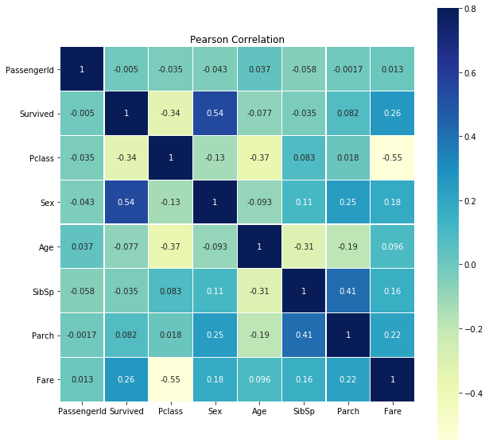

```python
corr=train_df.corr()
plt.figure(figsize=(10, 10))

sns.heatmap(corr, vmax=.8, linewidths=0.01,
            square=True,annot=True,cmap='YlGnBu',linecolor="white")
plt.title('Pearson Correlation');
```

#### Correlating categorical features

**Pclass** - It looks like the higher economic class you were the bigger the chance for survival you had

**Sex** - If you are a woman you have higher chance to survive

**Embarked** - Passengers from Cherbourg had higher chance for survival specialy men

**Parch and SibSp** - For higher values there is 0 correlation between the two, but lower values show some correlation

From the combination of Pclass,Embarked and Sex:

- High survival rate for women from upper class
- low survival rate for upper class man from Q (Queenstown)

```python
train_df[['Pclass', 'Survived']].groupby(['Pclass'], as_index=False).mean().sort_values(by='Survived', ascending=False)
```

|  | Pclass | Survived |
| --- | --- | --- |
| 0 | 1 | 0.629630 |
| 1 | 2 | 0.472826 |
| 2 | 3 | 0.242363 |

```python
train_df[['Sex', 'Survived']].groupby(['Sex'], as_index=False).mean().sort_values(by='Survived', ascending=False)
```

|  | Sex | Survived |
| --- | --- | --- |
| 1 | 1 | 0.742038 |
| 0 | 0 | 0.188908 |

```python
train_df[['Embarked', 'Survived']].groupby(['Embarked'], as_index=False).mean().sort_values(by='Survived', ascending=False)
```

|  | Embarked | Survived |
| --- | --- | --- |
| 0 | C | 0.553571 |
| 1 | Q | 0.389610 |
| 2 | S | 0.336957 |

```python
train_df[['Parch', 'Survived']].groupby(['Parch'], as_index=False).mean().sort_values(by='Survived', ascending=False)
```

|  | Parch | Survived |
| --- | --- | --- |
| 3 | 3 | 0.600000 |
| 1 | 1 | 0.550847 |
| 2 | 2 | 0.500000 |
| 0 | 0 | 0.343658 |
| 5 | 5 | 0.200000 |
| 4 | 4 | 0.000000 |
| 6 | 6 | 0.000000 |

```python
train_df[['SibSp', 'Survived']].groupby(['SibSp'], as_index=False).mean().sort_values(by='Survived', ascending=False)
```

|  | SibSp | Survived |
| --- | --- | --- |
| 1 | 1 | 0.535885 |
| 2 | 2 | 0.464286 |
| 0 | 0 | 0.345395 |
| 3 | 3 | 0.250000 |
| 4 | 4 | 0.166667 |
| 5 | 5 | 0.000000 |
| 6 | 8 | 0.000000 |

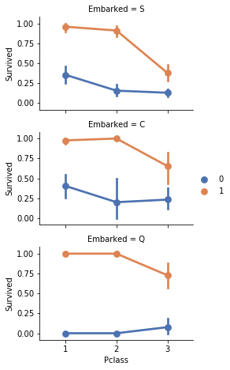

```python
grid = sns.FacetGrid(train_df, row='Embarked', size=2.2, aspect=1.6)
grid.map(sns.pointplot, 'Pclass', 'Survived', 'Sex', palette='deep')
grid.add_legend()
```

#### Correlating numerical features

1. Looks like infants mostly survived
2. Most 15-25 didn't survive
3. Passangers that payed less mostly didnt survive

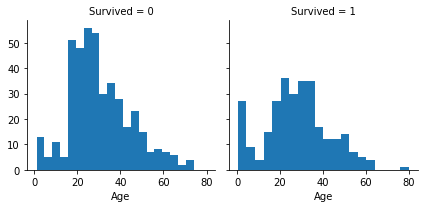

```python
g = sns.FacetGrid(train_df, col='Survived')
g.map(plt.hist, 'Age', bins=20)
```

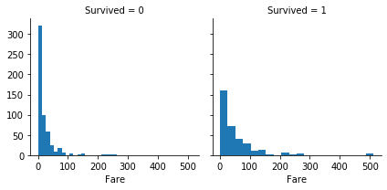

```python
g = sns.FacetGrid(train_df, col='Survived')
g.map(plt.hist, 'Fare',bins=20)
```

###### Deeper analyzes of high level correlations

1. Upper class varied in his Fare but there is strong signal that lower classes payed less
2. Passengers who didnt have spouses/siblings didnt have children/parents as well, but there is small signal showing that passengers that had 2 children/parents would probably have at least one spouses/siblings

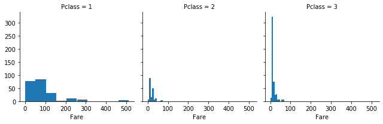

```python
g = sns.FacetGrid(train_df, col='Pclass')
g.map(plt.hist, 'Fare')
```

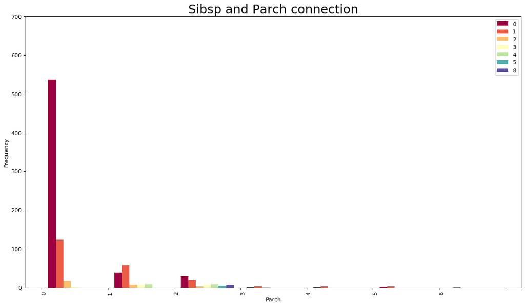

```python
barchar_group(train_df[["SibSp","Parch"]],"Parch","SibSp",700,"Sibsp and Parch connection")
```

#### Conclusion from observations and correlations analyses

1. Ticket - Will be dropped, to much duplicates
2. Cabin - will be dropped to much info is lost
3. Parch+SibSp - Those features will be combined to create family feature
4. Age - will be filled
5. Embarked - will be filled
6. Fare - will be filled
7. Name - Will be dropped as he has no impact on results after replacing it with Title feature.
8. PassengerID - Will be dropped as he has no impact on results

##### remove features

```python
for dataset in combine:
    dataset.drop(['Ticket', 'Cabin'], axis=1,inplace=True)
```

```python
train_df.drop("PassengerId", axis=1,inplace=True)
```

##### Adjust Pclass

```python
le = LabelEncoder()
le.fit(train_df.Pclass)

for dataset in combine:
    dataset.Pclass = le.transform(dataset.Pclass)
```

##### Create Title feature , extracting from name

Note: we create it her because we need to adjust age based on some features and title is one of them.

```python
for dataset in combine:
    dataset['Title'] = dataset.Name.str.split(", ", expand=True)[1].str.split(".", expand=True)[0]
```

###### Correcting Embarked

I will filling 'na' values with the most freq value for one main reason, there are only 2 values missing so noise is not an issue.

```python
train_df.loc[train_df.Embarked.isna(), 'Embarked'] = train_df.Embarked.mode()[0]

train_df.head()
```

|  | Survived | Pclass | Name | Sex | Age | SibSp | Parch | Fare | Embarked | Title |
| --- | --- | --- | --- | --- | --- | --- | --- | --- | --- | --- |
| 0 | 0 | 2 | Braund, Mr. Owen Harris | 0 | 22.0 | 1 | 0 | 7.2500 | S | Mr |
| 1 | 1 | 0 | Cumings, Mrs. John Bradley (Florence Briggs Th... | 1 | 38.0 | 1 | 0 | 71.2833 | C | Mrs |
| 2 | 1 | 2 | Heikkinen, Miss. Laina | 1 | 26.0 | 0 | 0 | 7.9250 | S | Miss |
| 3 | 1 | 0 | Futrelle, Mrs. Jacques Heath (Lily May Peel) | 1 | 35.0 | 1 | 0 | 53.1000 | S | Mrs |
| 4 | 0 | 2 | Allen, Mr. William Henry | 0 | 35.0 | 0 | 0 | 8.0500 | S | Mr |

Now we can convert the string values in Embarked to numeric feature

```python
for dataset in combine:
    dataset.Embarked = dataset.Embarked.map({"C": 2, "Q": 1, "S": 0})


train_df.head()
```

|  | Survived | Pclass | Name | Sex | Age | SibSp | Parch | Fare | Embarked | Title |
| --- | --- | --- | --- | --- | --- | --- | --- | --- | --- | --- |
| 0 | 0 | 2 | Braund, Mr. Owen Harris | 0 | 22.0 | 1 | 0 | 7.2500 | 0 | Mr |
| 1 | 1 | 0 | Cumings, Mrs. John Bradley (Florence Briggs Th... | 1 | 38.0 | 1 | 0 | 71.2833 | 2 | Mrs |
| 2 | 1 | 2 | Heikkinen, Miss. Laina | 1 | 26.0 | 0 | 0 | 7.9250 | 0 | Miss |
| 3 | 1 | 0 | Futrelle, Mrs. Jacques Heath (Lily May Peel) | 1 | 35.0 | 1 | 0 | 53.1000 | 0 | Mrs |
| 4 | 0 | 2 | Allen, Mr. William Henry | 0 | 35.0 | 0 | 0 | 8.0500 | 0 | Mr |

###### Correcting Age

```python
def fill_age_missing_values(df):
    age_null = list(df[df["Age"].isnull()].index)

    for index in age_null:
        temp_Pclass = df.iloc[index]["Pclass"]
        temp_SibSp = df.iloc[index]["SibSp"]
        temp_Parch = df.iloc[index]["Parch"]
        temp_Title = df.iloc[index]["Title"]

        age_median = df["Age"][(
            (df["Pclass"] == temp_Pclass) &
            (df["Pclass"] == temp_Pclass) &
            (df["SibSp"] == temp_SibSp) &
            (df["Parch"] == temp_Parch) &
            (df["Title"] == temp_Title)
        )].median()

        df["Age"].iloc[index] = age_median if (df.iloc[index]["Age"] == True) and (np.isnan(age_median) == False) else df["Age"].median()
    return df
```

```python
for dataset in combine:
    dataset = fill_age_missing_values(dataset)
train_df.head()
```

|  | Survived | Pclass | Name | Sex | Age | SibSp | Parch | Fare | Embarked | Title |
| --- | --- | --- | --- | --- | --- | --- | --- | --- | --- | --- |
| 0 | 0 | 2 | Braund, Mr. Owen Harris | 0 | 22.0 | 1 | 0 | 7.2500 | 0 | Mr |
| 1 | 1 | 0 | Cumings, Mrs. John Bradley (Florence Briggs Th... | 1 | 38.0 | 1 | 0 | 71.2833 | 2 | Mrs |
| 2 | 1 | 2 | Heikkinen, Miss. Laina | 1 | 26.0 | 0 | 0 | 7.9250 | 0 | Miss |
| 3 | 1 | 0 | Futrelle, Mrs. Jacques Heath (Lily May Peel) | 1 | 35.0 | 1 | 0 | 53.1000 | 0 | Mrs |
| 4 | 0 | 2 | Allen, Mr. William Henry | 0 | 35.0 | 0 | 0 | 8.0500 | 0 | Mr |

##### Correcting Fare

```python
test_df.loc[test_df.Fare.isna(), 'Fare'] = test_df[test_df.Pclass == 3].Fare.mean()
```

The Fare is highly skewed, let's apply a log function to tackle reduce the skewness

```python
for dataset in combine:
    dataset["Fare"] = dataset["Fare"].map(lambda x: np.log(x) if x > 0 else 0)
```

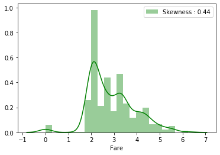

```python
sns.distplot(train_df["Fare"], color="g", label="Skewness : %.2f"%(train_df["Fare"].skew())).legend(loc="best")
```

# Feature Engineering

##### Create Age group

All the babies has survived.

```python
train_df[train_df.Age < 1].Survived.mean()
```

```
1.0
```

devide age to age group.

```python
age_groups = ['Baby',  'Child', 'Young Adult', 'Adult', 'Senior']

for dataset in combine:
    dataset.loc[(dataset['Age'] <= 2), 'Age Group'] = 0
    dataset.loc[((dataset["Age"] > 2) & (dataset['Age'] <= 10)), 'Age Group'] = 1
    dataset.loc[((dataset["Age"] > 10) & (dataset['Age'] <= 19)), 'Age Group'] = 2
    dataset.loc[((dataset["Age"] > 19) & (dataset['Age'] <= 60)), 'Age Group'] = 3
    dataset.loc[(dataset["Age"] > 60), 'Age Group'] = 4

    dataset["Age"] = dataset["Age"].astype(int)
    dataset["Age Group"] = dataset["Age Group"].astype(int)
```

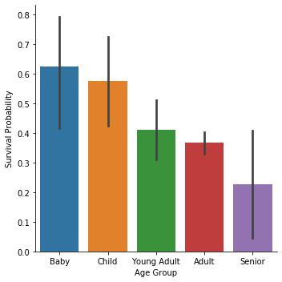

```python
sns.factorplot(x="Age Group", y="Survived", data=train_df, kind="bar").set_xticklabels(age_groups).set_ylabels("Survival Probability")
```

Now i can drop Age safely.

```python
for dataset in combine:
    dataset.drop(['Age'], axis=1,inplace=True)
train_df.head()
```

|  | Survived | Pclass | Name | Sex | SibSp | Parch | Fare | Embarked | Title | Age Group |
| --- | --- | --- | --- | --- | --- | --- | --- | --- | --- | --- |
| 0 | 0 | 2 | Braund, Mr. Owen Harris | 0 | 1 | 0 | 1.981001 | 0 | Mr | 3 |
| 1 | 1 | 0 | Cumings, Mrs. John Bradley (Florence Briggs Th... | 1 | 1 | 0 | 4.266662 | 2 | Mrs | 3 |
| 2 | 1 | 2 | Heikkinen, Miss. Laina | 1 | 0 | 0 | 2.070022 | 0 | Miss | 3 |
| 3 | 1 | 0 | Futrelle, Mrs. Jacques Heath (Lily May Peel) | 1 | 1 | 0 | 3.972177 | 0 | Mrs | 3 |
| 4 | 0 | 2 | Allen, Mr. William Henry | 0 | 0 | 0 | 2.085672 | 0 | Mr | 3 |

##### Adjust Title

When we plot Title, and Survived, we note the following observations.

- Survival among Title varies slightly.
- Certain titles mostly survived (Mme, Lady, Sir) or did not (Don, Rev, Jonkheer).

```python
pd.crosstab(train_df['Title'], train_df['Survived'])
```

| Survived Title | 0 | 1 |
| --- | --- | --- |
| Capt | 1 | 0 |
| Col | 1 | 1 |
| Don | 1 | 0 |
| Dr | 4 | 3 |
| Jonkheer | 1 | 0 |
| Lady | 0 | 1 |
| Major | 1 | 1 |
| Master | 17 | 23 |
| Miss | 55 | 127 |
| Mlle | 0 | 2 |
| Mme | 0 | 1 |
| Mr | 436 | 81 |
| Mrs | 26 | 99 |
| Ms | 0 | 1 |
| Rev | 6 | 0 |
| Sir | 0 | 1 |
| the Countess | 0 | 1 |

```python
titles = ["Master", "Miss", "Mr", "Royals", "Professionals"]

for dataset in combine:
    dataset.Title = dataset.Title.replace(['Lady', 'the Countess', 'Countess', 'Don', 'Jonkheer', 'Dona', 'Sir'], 'Royals')
    dataset.Title = dataset.Title.replace(['Col', 'Dr', 'Major', 'Capt'], 'Professionals')
    dataset.Title = dataset.Title.replace(["Ms", "Mme", "Mlle", "Mrs"], 'Miss')
    dataset.Title = dataset.Title.replace(['Master', 'Rev'], 'Mas/Rev')
```

Check new correlations

[figure not shown]

```python
sns.factorplot(x="Title", y="Survived", data=train_df, kind="bar").set_xticklabels(titles).set_ylabels("Survival Probability")
```

map titels to numerical values

```python
for dataset in combine:
    dataset.Title = dataset.Title.map({"Mas/Rev": 0, "Miss": 1, "Mr": 2, "Royals": 3, "Professionals": 4})
```

Now I can drop Name safely

```python
for dataset in combine:
    dataset.drop('Name', axis=1, inplace=True)
train_df.head()
```

|  | Survived | Pclass | Sex | SibSp | Parch | Fare | Embarked | Title | Age Group |
| --- | --- | --- | --- | --- | --- | --- | --- | --- | --- |
| 0 | 0 | 2 | 0 | 1 | 0 | 1.981001 | 0 | 2 | 3 |
| 1 | 1 | 0 | 1 | 1 | 0 | 4.266662 | 2 | 1 | 3 |
| 2 | 1 | 2 | 1 | 0 | 0 | 2.070022 | 0 | 1 | 3 |
| 3 | 1 | 0 | 1 | 1 | 0 | 3.972177 | 0 | 1 | 3 |
| 4 | 0 | 2 | 0 | 0 | 0 | 2.085672 | 0 | 2 | 3 |

As seen before the "Fare" is continuous variable, we can split it to bands and check correlation to "Survived"

```python
train_df['FareBand'] = pd.qcut(train_df['Fare'], 4)
train_df[['FareBand', 'Survived']].groupby(['FareBand'], as_index=False).mean().sort_values(by='FareBand', ascending=True)
```

|  | FareBand | Survived |
| --- | --- | --- |
| 0 | (-0.001, 2.068] | 0.197309 |
| 1 | (2.068, 2.671] | 0.303571 |
| 2 | (2.671, 3.434] | 0.454955 |
| 3 | (3.434, 6.239] | 0.581081 |

There is strong correlation between multiple bands so we will make it a categorical variable

```python
for dataset in combine:
    dataset.loc[ dataset['Fare'] <= 2.068, 'Fare'] = 0
    dataset.loc[(dataset['Fare'] > 2.068) & (dataset['Fare'] <= 2.671), 'Fare'] = 1
    dataset.loc[(dataset['Fare'] > 2.671) & (dataset['Fare'] <= 3.434), 'Fare']   = 2
    dataset.loc[ dataset['Fare'] > 3.434, 'Fare'] = 3
    dataset['Fare'] = dataset['Fare'].astype(int)

train_df = train_df.drop(['FareBand'], axis=1)
combine = [train_df, test_df]

train_df.head()
```

|  | Survived | Pclass | Sex | SibSp | Parch | Fare | Embarked | Title | Age Group |
| --- | --- | --- | --- | --- | --- | --- | --- | --- | --- |
| 0 | 0 | 2 | 0 | 1 | 0 | 0 | 0 | 2 | 3 |
| 1 | 1 | 0 | 1 | 1 | 0 | 3 | 2 | 1 | 3 |
| 2 | 1 | 2 | 1 | 0 | 0 | 1 | 0 | 1 | 3 |
| 3 | 1 | 0 | 1 | 1 | 0 | 3 | 0 | 1 | 3 |
| 4 | 0 | 2 | 0 | 0 | 0 | 1 | 0 | 2 | 3 |

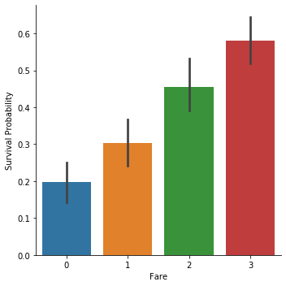

```python
sns.factorplot(x="Fare", y="Survived", data=train_df, kind="bar").set_xticklabels([0,1,2,3]).set_ylabels("Survival Probability")
```

##### Create Family

According to the coorelation check there is a logic of engineering Parch and SibSp, we will create feature called family which is combination of them.

```python
for dataset in combine:
    dataset["Family"] = dataset["Parch"]+dataset["SibSp"]

train_df.head()
```

|  | Survived | Pclass | Sex | SibSp | Parch | Fare | Embarked | Title | Age Group | Family |
| --- | --- | --- | --- | --- | --- | --- | --- | --- | --- | --- |
| 0 | 0 | 2 | 0 | 1 | 0 | 0 | 0 | 2 | 3 | 1 |
| 1 | 1 | 0 | 1 | 1 | 0 | 3 | 2 | 1 | 3 | 1 |
| 2 | 1 | 2 | 1 | 0 | 0 | 1 | 0 | 1 | 3 | 0 |
| 3 | 1 | 0 | 1 | 1 | 0 | 3 | 0 | 1 | 3 | 1 |
| 4 | 0 | 2 | 0 | 0 | 0 | 1 | 0 | 2 | 3 | 0 |

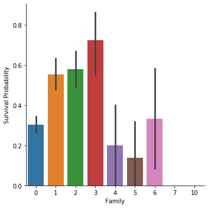

```python
sns.factorplot(x="Family", y="Survived", data=train_df, kind="bar").set_ylabels("Survival Probability")
```

Now I can drop Parch and SibSp and just use family feature

```python
for dataset in combine:
    dataset.drop(["Parch","SibSp"],axis=1,inplace = True)
train_df.head()
```

|  | Survived | Pclass | Sex | Fare | Embarked | Title | Age Group | Family |
| --- | --- | --- | --- | --- | --- | --- | --- | --- |
| 0 | 0 | 2 | 0 | 0 | 0 | 2 | 3 | 1 |
| 1 | 1 | 0 | 1 | 3 | 2 | 1 | 3 | 1 |
| 2 | 1 | 2 | 1 | 1 | 0 | 1 | 3 | 0 |
| 3 | 1 | 0 | 1 | 3 | 0 | 1 | 3 | 1 |
| 4 | 0 | 2 | 0 | 1 | 0 | 2 | 3 | 0 |

Lets take a look at the new correlations created in the new dataset. It can be seen that in total we have much more correlation between the different features that should help us to get a stronger signal from the dataset.

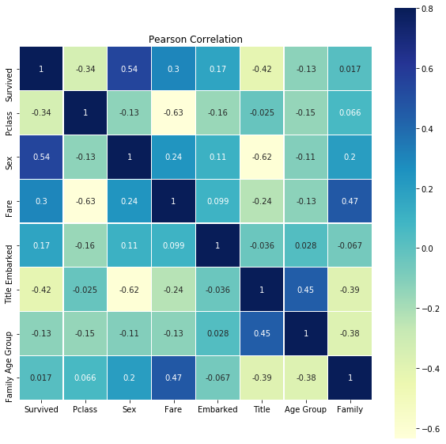

```python
corr=train_df.corr()
plt.figure(figsize=(10, 10))

sns.heatmap(corr, vmax=.8, linewidths=0.01,
            square=True,annot=True,cmap='YlGnBu',linecolor="white")
plt.title('Pearson Correlation');
```

## PCA data visualization

Now lets visualize in 3D the data to get an insight of how the new data looks like

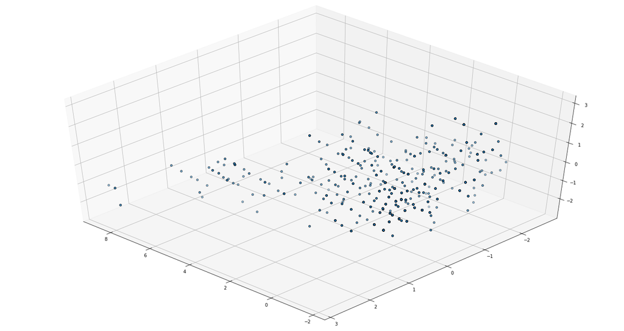

```python
viz_df = pca_conversion(train_df)
fig = plt.figure(figsize=(20,10))
plt.clf()
ax = Axes3D(fig, rect=[0, 0, .95, 1], elev=48, azim=134)

ax.scatter(viz_df["x"], viz_df["y"], viz_df["z"], cmap=plt.cm.nipy_spectral,
           edgecolor='k')
```

# Machine Learning - Models

Next stage will have the same models, but we will add clustering feature to it.

# NOTE: Feature selection was removed, scores were low from tests we did

#### Prepare data for models training

```python
preds = list(train_df.columns)
preds.remove('Survived')
test_columns = np.array(["PassengerId"])

x_train = train_df[preds]
y_train = train_df.Survived

x_test = test_df[preds]

kaggle_test = test_df[test_columns]
k_fold = StratifiedKFold(n_splits=5)
```

```python
x_train.head()
```

|  | Pclass | Sex | Fare | Embarked | Title | Age Group | Family |
| --- | --- | --- | --- | --- | --- | --- | --- |
| 0 | 2 | 0 | 0 | 0 | 2 | 3 | 1 |
| 1 | 0 | 1 | 3 | 2 | 1 | 3 | 1 |
| 2 | 2 | 1 | 1 | 0 | 1 | 3 | 0 |
| 3 | 0 | 1 | 3 | 0 | 1 | 3 | 1 |
| 4 | 2 | 0 | 1 | 0 | 2 | 3 | 0 |

```python
x_test.head()
```

|  | Pclass | Sex | Fare | Embarked | Title | Age Group | Family |
| --- | --- | --- | --- | --- | --- | --- | --- |
| 0 | 2 | 0 | 0 | 1 | 2 | 3 | 0 |
| 1 | 2 | 1 | 0 | 0 | 1 | 3 | 1 |
| 2 | 1 | 0 | 1 | 1 | 2 | 4 | 0 |
| 3 | 2 | 0 | 1 | 0 | 2 | 3 | 0 |
| 4 | 2 | 1 | 1 | 0 | 1 | 3 | 2 |

#### DecisionTree Classifier

Decision Treesare a non-parametric supervised learning method used for classification and regression. The goal is to create a model that predicts the value of a target variable by learning simple decision rules inferred from the data features.

Parameters defintion and using cross-validation to score to optimize the model

```python
param_grid ={'criterion':['gini', 'entropy'],
             'max_depth':[2,3,4,5,6,7,8,9,10],
             'min_samples_split':[2,3,4,5,6,7,8]
            }

# Create a grid search object
gsDCT = GridSearchCV(DecisionTreeClassifier(random_state = RSEED), param_grid, cv=5, scoring='accuracy')

# Fit the grid search
gsDCT = gsDCT.fit(x_train, y_train)
```

```python
print("Accuracy score {}".format(gsDCT.best_score_))
print("Best parameters {}".format(gsDCT.best_params_))

model = gsDCT.best_estimator_
```

```
Accuracy score 0.8327474734793799
Best parameters {'criterion': 'entropy', 'max_depth': 4, 'min_samples_split': 2}
```

```python
kaggle_test["Survived"] = model.predict(x_test)
kaggle_test.to_csv("DT.csv",index=False)
```

Kaggle accuracy score: 0.78468

Descition Trees - classification model, works great for categorical data. So the decision based on the different categories managed to were quit good.

#### RandomForest Classifier

RandomForest is classification model which is based on mulitple subtrees

First we define parameters used by the model

```python
param_grid = {
    "max_depth": [None],
    "max_features": [1, 3, 7, None],
    "min_samples_split": [2, 3, 8],
    "min_samples_leaf": [1, 3, 10],
    "bootstrap": [False],
    "n_estimators" :[100, 200, 300],
    "criterion": ["entropy"]
}
```

Optimize the RandomForest and output results

```python
rs = GridSearchCV(RandomForestClassifier(random_state=RSEED), param_grid, n_jobs=-1,
                        scoring='accuracy', cv=k_fold,
                        verbose=1)

rs = rs.fit(x_train,y_train)
```

```
Fitting 5 folds for each of 108 candidates, totalling 540 fits
```

```
[Parallel(n_jobs=-1)]: Using backend LokyBackend with 8 concurrent workers.
[Parallel(n_jobs=-1)]: Done  34 tasks      | elapsed:    3.9s
[Parallel(n_jobs=-1)]: Done 184 tasks      | elapsed:   17.9s
[Parallel(n_jobs=-1)]: Done 434 tasks      | elapsed:   39.9s
[Parallel(n_jobs=-1)]: Done 540 out of 540 | elapsed:   52.1s finished
```

```python
print("Accuracy score {}".format(rs.best_score_))
print("Best parameters {}".format(rs.best_params_))

model = rs.best_estimator_
```

```
Accuracy score 0.8339087314041805
Best parameters {'bootstrap': False, 'criterion': 'entropy', 'max_depth': None, 'max_features': 3, 'min_samples_leaf': 1, 'min_samples_split': 8, 'n_estimators': 200}
```

```python
kaggle_test["Survived"] = model.predict(x_test)
kaggle_test.to_csv("RF.csv",index=False)
```

Kaggle accuracy score: 0.76076

RandomForest is a powerhouse for classification problems. Having different trees that are based on categorical data should have good preformance on this type of dataset. The evaluation confirms it but the test results fail in it. Maybe the dataset has to much correlation in it which created wrong signal.

###### SVM

Support-vector machines are supervised learning models with associated learning algorithms that analyze data used for classification and regression analysis.

Define parameters used by the model

```python
tuned_parameters = {
    "kernel":["linear","rbf"] ,
    'degree': [2,3,4,5,6,7],
    'gamma': [0.00001,0.0001,0.001,0.01,0.1,1],
    'C': [1, 10, 100, 1000]

}
```

```python
gsSVMC = GridSearchCV(SVC(random_state=RSEED),param_grid = tuned_parameters, cv=k_fold, scoring="accuracy", n_jobs= -1, verbose = 1)
gsSVMC = gsSVMC.fit(x_train,y_train)
```

```
Fitting 5 folds for each of 288 candidates, totalling 1440 fits
```

```
[Parallel(n_jobs=-1)]: Using backend LokyBackend with 8 concurrent workers.
[Parallel(n_jobs=-1)]: Done  56 tasks      | elapsed:    0.2s
[Parallel(n_jobs=-1)]: Done 920 tasks      | elapsed:   13.6s
[Parallel(n_jobs=-1)]: Done 1170 tasks      | elapsed:   48.8s
[Parallel(n_jobs=-1)]: Done 1440 out of 1440 | elapsed:  2.3min finished
```

```python
print("Accuracy score {}".format(gsSVMC.best_score_))
print("Best parameters {}".format(gsSVMC.best_params_))

model = gsSVMC.best_estimator_
```

```
Accuracy score 0.8305191136777352
Best parameters {'C': 100, 'degree': 2, 'gamma': 0.01, 'kernel': 'rbf'}
```

```python
kaggle_test["Survived"] = model.predict(x_test)
kaggle_test.to_csv("SVM.csv",index=False)
```

Kaggle accuracy score: 0.79425

###### KNN

Neighbors-based classification is a type of instance-based learning or non-generalizing learning Classification is computed from a simple majority vote of the nearest neighbors of each point.

We choose the number of neighbors for optimization by using cross-validation method

```python
neighbors = list(range(1,50,2))


cv_scores = [ ]
for K in neighbors:
    knn = KNeighborsClassifier(n_neighbors = K)
    scores = cross_val_score(knn,x_train,y_train,cv = 10,scoring =
    "accuracy")
    cv_scores.append(scores.mean())
```

Choosing best K("number of neighbors")

```python
mse = [1-x for x in cv_scores]
optimal_k = neighbors[mse.index(min(mse))]
print("The optimal no. of neighbors is {}".format(optimal_k))
```

```
The optimal no. of neighbors is 33
```

```python
knn = KNeighborsClassifier(n_neighbors=optimal_k, metric='euclidean')
knn = knn.fit(x_train, y_train)
```

```python
print("Accuracy score {}".format(knn.score(x_train, y_train)))
print("Best parameters {}".format(knn.get_params()))
```

```
Accuracy score 0.8249158249158249
Best parameters {'algorithm': 'auto', 'leaf_size': 30, 'metric': 'euclidean', 'metric_params': None, 'n_jobs': None, 'n_neighbors': 33, 'p': 2, 'weights': 'uniform'}
```

```python
kaggle_test["Survived"] = knn.predict(x_test)
kaggle_test.to_csv("KNN.csv",index=False)
```

Kaggle accuracy score: 0.7799

KNN managed to preform pretty well, with 33 neighbors that as optimal number to chose by in this dataset.

###### Neural Nets

Multi-layer Perceptron classifier.

```python
parameter_space = {
    'hidden_layer_sizes': [(50,50,50), (50,100,50), (100,)],
    'activation': ['tanh', 'relu'],
    'solver': ['sgd', 'adam'],
    'alpha': [0.0001, 0.05],
    'learning_rate': ['constant','adaptive'],
}
```

Using cross-validation for tuning hyperparameters

```python
clf = GridSearchCV( MLPClassifier(max_iter=100,random_state=RSEED), parameter_space, n_jobs=-1, cv=k_fold)
clf = clf.fit(x_train, y_train)
```

```python
print("Accuracy score {}".format(clf.best_score_))
print("Best parameters {}".format(clf.best_params_))

model = clf.best_estimator_
```

```
Accuracy score 0.8226476680685456
Best parameters {'activation': 'tanh', 'alpha': 0.0001, 'hidden_layer_sizes': (50, 100, 50), 'learning_rate': 'constant', 'solver': 'adam'}
```

```python
kaggle_test["Survived"] = model.predict(x_test)
kaggle_test.to_csv("NN.csv",index=False)
```

Kaggle accuracy score: 0.78468

3 layers were used in this case, this is quit a small nerual net, probably showed have used more layers to get better results from a powerhouse for classification as nerual nets.

###### Bagging

A Bagging classifier is an ensemble meta-estimator that fits base classifiers each on random subsets of the original dataset and then aggregate their individual predictions (either by voting or by averaging) to form a final prediction.

```python
params = {
    "n_estimators" :[100, 200, 300],
    'base_estimator__max_leaf_nodes':[10, 15],
    'base_estimator__max_depth':[4, 5, 6],
    'max_samples' : [0.05, 0.1, 0.2, 0.5]

}
```

Using cross-validation for tuning hyperparameters

```python
clf = GridSearchCV(BaggingClassifier(DecisionTreeClassifier()),params, scoring =  "accuracy")

clf = clf.fit(x_train, y_train)
```

```python
print("Accuracy score {}".format(clf.best_score_))
print("Best parameters {}".format(clf.best_params_))

model = clf.best_estimator_
```

```
Accuracy score 0.8282719226664993
Best parameters {'base_estimator__max_depth': 6, 'base_estimator__max_leaf_nodes': 10, 'max_samples': 0.5, 'n_estimators': 100}
```

```python
kaggle_test["Survived"] = model.predict(x_test)
kaggle_test.to_csv("BAGGGING.csv",index=False)
```

Kaggle accuracy score: 0.79904

## Summery

[figure not shown]

# Dataset + Clustering Feature

### GMM

A Gaussian mixture model is a probabilistic model that assumes all the data points are generated from a mixture of a finite number of Gaussian distributions with unknown parameters. One can think of mixture models as generalizing k-means clustering to incorporate information about the covariance structure of the data as well as the centers of the latent Gaussians.

To choose the best parameters for the model we will use silhouette, and choose the best parameters according to it

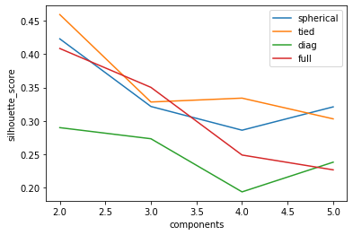

```python
evluate_sil = {}
n_components_range = range(2, 6)
cv_types = ['spherical', 'tied', 'diag', 'full']

# checking what are the best parameters for GMM
for cv_type in cv_types:

    sil = []
    for n_components in n_components_range:
        # Fit a Gaussian mixture with EM
        gmm = mixture.GaussianMixture(n_components=n_components,
                                      covariance_type=cv_type,random_state=RSEED)
        gmm.fit(x_train)
        labels = gmm.predict(x_train)
        sil.append(silhouette_score(x_train, labels, metric = 'euclidean'))

    evluate_sil[cv_type] = sil



for key in evluate_sil:
    plt.plot(n_components_range, evluate_sil[key],label=key) # plotting t, c separately

plt.xlabel("components")
plt.ylabel("silhouette_score")
plt.legend(loc=1)
plt.show()
```

```python
gmm = mixture.GaussianMixture(n_components=2, covariance_type=cv_type,random_state=RSEED)

x_train["Cluster"] = gmm.fit_predict(x_train)
x_test["Cluster"] = gmm.predict(x_test)
```

## Models analysis

### NOTE: There will be no description added to the models because all the process was explained in the section above

```python
features = np.array(["Pclass","Sex","Age","Fare","Embarked","Family","Cluster"])
target = "Survived"
test_columns = np.array(["PassengerId"])
```

#### DecisionTree Classifier

```python
param_grid ={'criterion':['gini', 'entropy'],
             'max_depth':[2,3,4,5,6,7,8,9,10],
             'min_samples_split':[2,3,4,5,6,7,8]
            }

# Create a grid search object
gsDCT = GridSearchCV(DecisionTreeClassifier(), param_grid, cv=5, scoring='accuracy')

# Fit the grid search
gsDCT = gsDCT.fit(x_train, y_train)
```

```python
print("Accuracy score {}".format(gsDCT.best_score_))
print("Best parameters {}".format(gsDCT.best_params_))

model = gsDCT.best_estimator_
```

```
Accuracy score 0.8338710689849979
Best parameters {'criterion': 'entropy', 'max_depth': 4, 'min_samples_split': 4}
```

```python
kaggle_test["Survived"] = model.predict(x_test)
kaggle_test.to_csv("DT_CLUSTER.csv",index=False)
```

Kaggle accuracy score: 0.78468

The feature had small effect on the evaluation score and no effect on the test score

#### RandomForest Classifier

```python
param_grid = {
    'n_estimators': [100, 150, 200, 250],#The number of trees in the forest.
    'max_depth': [None, 50, 60, 70] ,#The maximum depth of the tree.
    'max_features': ['sqrt', None],#he number of features to consider when looking for the best split
    'min_samples_split': [2, 5, 10],#The minimum number of samples required to split an internal node
    'bootstrap': [True, False]#Whether bootstrap samples are used when building trees.
}
```

```python
rs = GridSearchCV(RandomForestClassifier(random_state=RSEED), param_grid, n_jobs=-1,
                        scoring='accuracy', cv=k_fold,
                        verbose=1)

rs = rs.fit(x_train,y_train)
```

```
Fitting 5 folds for each of 192 candidates, totalling 960 fits
```

```
[Parallel(n_jobs=-1)]: Using backend LokyBackend with 8 concurrent workers.
[Parallel(n_jobs=-1)]: Done  34 tasks      | elapsed:    2.3s
[Parallel(n_jobs=-1)]: Done 184 tasks      | elapsed:   17.3s
[Parallel(n_jobs=-1)]: Done 434 tasks      | elapsed:   42.0s
[Parallel(n_jobs=-1)]: Done 784 tasks      | elapsed:  1.2min
[Parallel(n_jobs=-1)]: Done 960 out of 960 | elapsed:  1.4min finished
```

```python
print("Accuracy score {}".format(rs.best_score_))
print("Best parameters {}".format(rs.best_params_))

model = rs.best_estimator_
```

```
Accuracy score 0.8338961772644529
Best parameters {'bootstrap': True, 'max_depth': None, 'max_features': 'sqrt', 'min_samples_split': 10, 'n_estimators': 150}
```

```python
kaggle_test["Survived"] = model.predict(x_test)
kaggle_test.to_csv("RF_CLUSTER.csv",index=False)
```

Kaggle accuracy score: 0.76555

Feature added noise to dataset, which had minor effect on the evaluation score and on the test score

###### SVM

```python
tuned_parameters = {
    "kernel":["linear","rbf"] ,
    'degree': [2,3,4,5,6,7],
    'gamma': [0.00001,0.0001,0.001,0.01,0.1,1],
    'C': [1, 10, 100, 1000]

}
```

```python
gsSVMC = GridSearchCV(SVC(),param_grid = tuned_parameters, cv=3, scoring="accuracy", n_jobs= -1, verbose = 1)
gsSVMC =gsSVMC.fit(x_train,y_train)
```

```
Fitting 3 folds for each of 288 candidates, totalling 864 fits
```

```
[Parallel(n_jobs=-1)]: Using backend LokyBackend with 8 concurrent workers.
[Parallel(n_jobs=-1)]: Done  56 tasks      | elapsed:    0.2s
[Parallel(n_jobs=-1)]: Done 696 tasks      | elapsed:   17.6s
[Parallel(n_jobs=-1)]: Done 864 out of 864 | elapsed:   48.1s finished
```

```python
print("Accuracy score {}".format(gsSVMC.best_score_))
print("Best parameters {}".format(gsSVMC.best_params_))

model = gsSVMC.best_estimator_
```

```
Accuracy score 0.8294051627384961
Best parameters {'C': 100, 'degree': 2, 'gamma': 0.01, 'kernel': 'rbf'}
```

```python
kaggle_test["Survived"] = gsSVMC.predict(x_test)
kaggle_test.to_csv("SVM_CLUSTER.csv",index=False)
```

Kaggle accuracy score: 0.79425

###### KNN

```python
neighbors = list(range(1,50,2))

cv_scores = [ ]
for K in neighbors:
    knn = KNeighborsClassifier(n_neighbors = K)
    scores = cross_val_score(knn,x_train,y_train,cv = 10,scoring =
    "accuracy")
    cv_scores.append(scores.mean())
```

```python
mse = [1-x for x in cv_scores]
optimal_k = neighbors[mse.index(min(mse))]
print("The optimal no. of neighbors is {}".format(optimal_k))
```

```
The optimal no. of neighbors is 29
```

```python
knn = KNeighborsClassifier(n_neighbors=optimal_k, metric='euclidean')
knn = knn.fit(x_train, y_train)
```

```python
print("Accuracy score {}".format(knn.score(x_train, y_train)))
print("Best parameters {}".format(knn.get_params()))
```

```
Accuracy score 0.8282828282828283
Best parameters {'algorithm': 'auto', 'leaf_size': 30, 'metric': 'euclidean', 'metric_params': None, 'n_jobs': None, 'n_neighbors': 29, 'p': 2, 'weights': 'uniform'}
```

```python
kaggle_test["Survived"] = knn.predict(x_test)
kaggle_test.to_csv("KNN_CLUSTER.csv",index=False)
```

Kaggle accuracy score: 0.7799

The introduction of the new feature had a minor effect on the evaluation and test scores

###### Neural Nets

```python
parameter_space = {
    'hidden_layer_sizes': [(50,50,50), (50,100,50), (100,)],
    'activation': ['tanh', 'relu'],
    'solver': ['sgd', 'adam'],
    'alpha': [0.0001, 0.05],
    'learning_rate': ['constant','adaptive'],
}
```

```python
clf = GridSearchCV(MLPClassifier(max_iter=100), parameter_space, n_jobs=-1, cv=3)
clf = clf.fit(x_train, y_train)
```

```python
print("Accuracy score {}".format(clf.best_score_))
print("Best parameters {}".format(clf.best_params_))

model = clf.best_estimator_
```

```
Accuracy score 0.8249158249158249
Best parameters {'activation': 'tanh', 'alpha': 0.05, 'hidden_layer_sizes': (50, 50, 50), 'learning_rate': 'constant', 'solver': 'adam'}
```

```python
kaggle_test["Survived"] = model.predict(x_test)
kaggle_test.to_csv("NN_CLUSTER.csv",index=False)
```

Kaggle accuracy score: 0.77990

###### Bagging

```python
params = {
    "n_estimators" :[100, 200, 300],
    'base_estimator__max_leaf_nodes':[10, 15],
    'base_estimator__max_depth':[4, 5, 6],
    'max_samples' : [0.05, 0.1, 0.2, 0.5]

}
```

```python
clf = GridSearchCV(BaggingClassifier(DecisionTreeClassifier()),params, scoring =  "accuracy")

clf = clf.fit(x_train, y_train)
```

```python
print("Accuracy score {}".format(clf.best_score_))
print("Best parameters {}".format(clf.best_params_))

model = clf.best_estimator_
```

```
Accuracy score 0.8293955181721172
Best parameters {'base_estimator__max_depth': 4, 'base_estimator__max_leaf_nodes': 10, 'max_samples': 0.5, 'n_estimators': 200}
```

```python
kaggle_test["Survived"] = model.predict(x_test)
kaggle_test.to_csv("BAGGGING_CLUSTER.csv",index=False)
```

Kaggle accuracy score: 0.78468

## Summery

[figure not shown]

# Discussion

A little summery of what was done in the notebook

###### Dropping

The data given to us was a little corrupted, features that contained alot of missing values and alot of added value which was hidden inside the "Name" feature. Features as "PassengerID" , "Cabin" and "Ticket" were dropped.

**"Name"** - After extracting the title from the name, the feature shoudn't have any impact on the results

**"PassengerID"** - Have no effect on the result, so he was dropped

###### Correcting

Then filling process started. "Age", "Embarked" and "Fare" were completed, because they showed some correlation to "Survived". Every feature was completed under different logic.

**"Embarked"** - most frequent value was used

###### Feat

After filling was completed, feature engineering started. We wanted to create extra value by manipulating the existing features.  
The next features were created: "Fare","Title","Age Group" and Family

**"Fare"** - Was changed to categorical feature according to the correlations

**"Age Group"** - different age groups had different chances for survival, which made sense to create a categorical feature

**"Title"** - People with high ranking titles had higher chances for survivability so using the title as a categorical feature made sense

By optimizimg the different models we managed to get good evaluations for the models. In general the models preformed quit well in this dataset, with "accuracy" rate around 0.78. Even by adding an extra feature (which added mainly noise) the prefomance of the models wasnt effected in a harsh way.